# Loan From Prosper Data Exploration

## Dataset Overview

> This data set contains 113,937 loans with 81 variables on each loan, including loan amount, borrower rate (or interest rate), current loan status, borrower income, and many others. After examining the data and perform some data cleaning. The dataset was reduced to 113912 loans with 14 varibable. The dataset can be found [here](https://s3.amazonaws.com/udacity-hosted-downloads/ud651/prosperLoanData.csv), with feature documentation available [here](https://docs.google.com/spreadsheets/d/1gDyi_L4UvIrLTEC6Wri5nbaMmkGmLQBk-Yx3z0XDEtI/edit#gid=0).

## Compare all numerical plot

> Make a pairplot to compare all numerical plot so see how each variable correlate with others. he BorrowerAPR and BorrowerRate dimensions are highly correlated. Also MonthlyLoanPayment and LoanOriginalAmount dimensions are positively correlated. StatedMonthlyIncome show little or no correlation with MonthlyLoanPayment which implies that monthly income does not directly determine monthly loan payment amount.

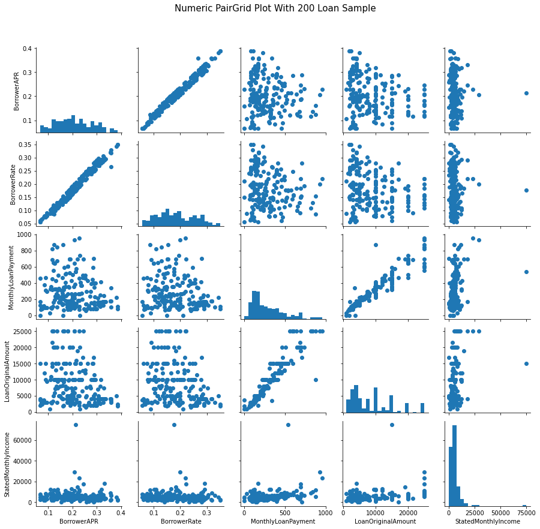

## BorrowerRate and BorrowerAPR vs Term Respectively

> To shows that for Term 60, the BorrowerRate and BorrowerAPR has few variety compare to Term 36 with high variety of BorrowerRate and BorrowerAPR. It suggest that loans in Term 60 has high level of agreement on BorrowerRate value and BorrowerAPR value.

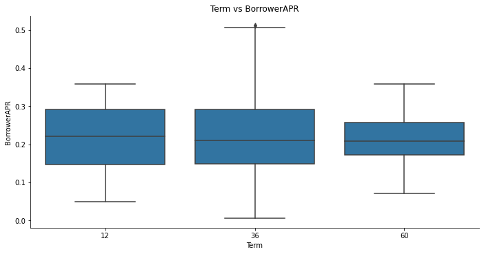

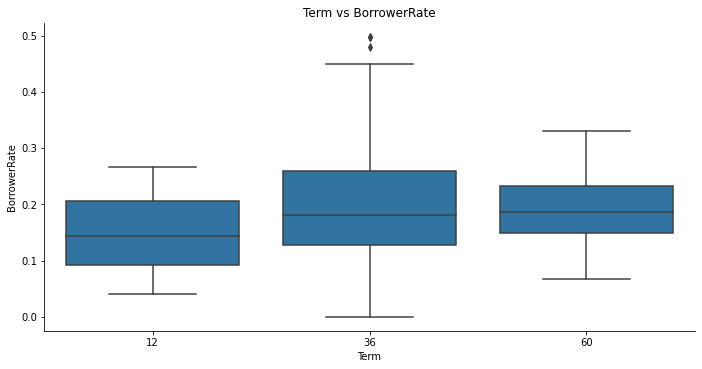

## IncomeVerifiable vs Other Categorical Variable

> majority of employmentstatus have varifiable income except selfemployed which have majority of unverifiable income. Similar to employmentstatus, loanstatus indicates that majority of the loans are to borrowers with verifiable income and the same result was obtained for listing category. It can be observed that majority of the loans are given to those with verifiable income.

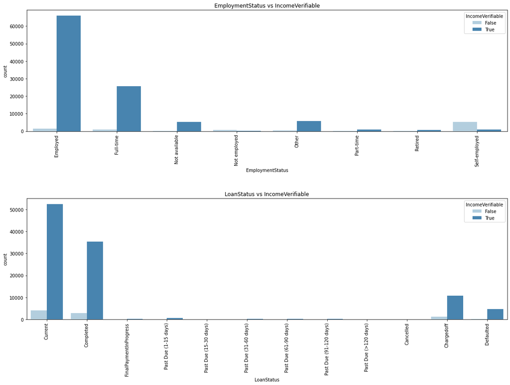

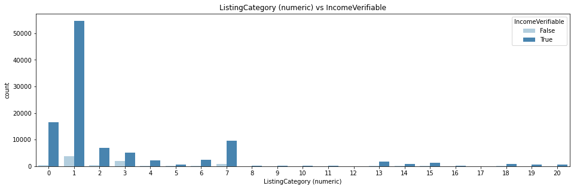

## LoanOriginalAmount vs StatedMonthlyIncome

> Applying log scale on the StatedMonthlyIncome axis, the plot shows that majority of the borrowers earns amount which lies in between 100 to 100k dollar. Also number of loans decrease as the amount increases. It also show that StatedMonthlyIncome and LoanOriginalAmount has close to zero correlation

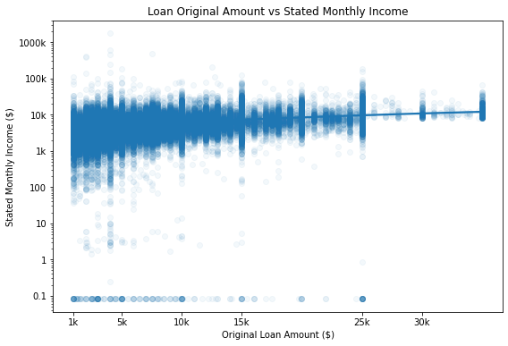